# Regression Model for [Project Name] Using R version 11

### 2.b) Data visualizations

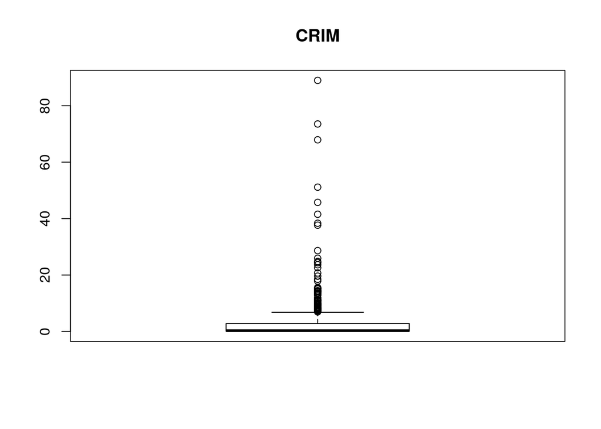

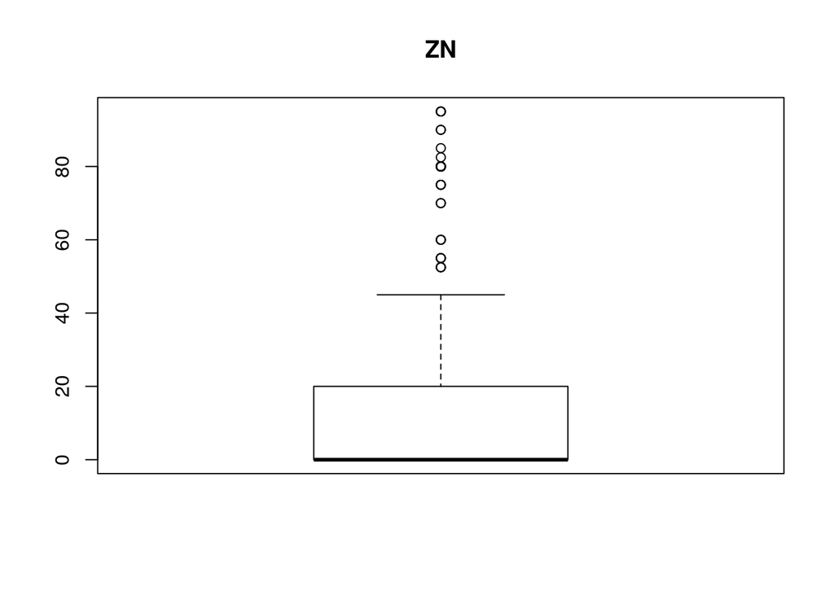

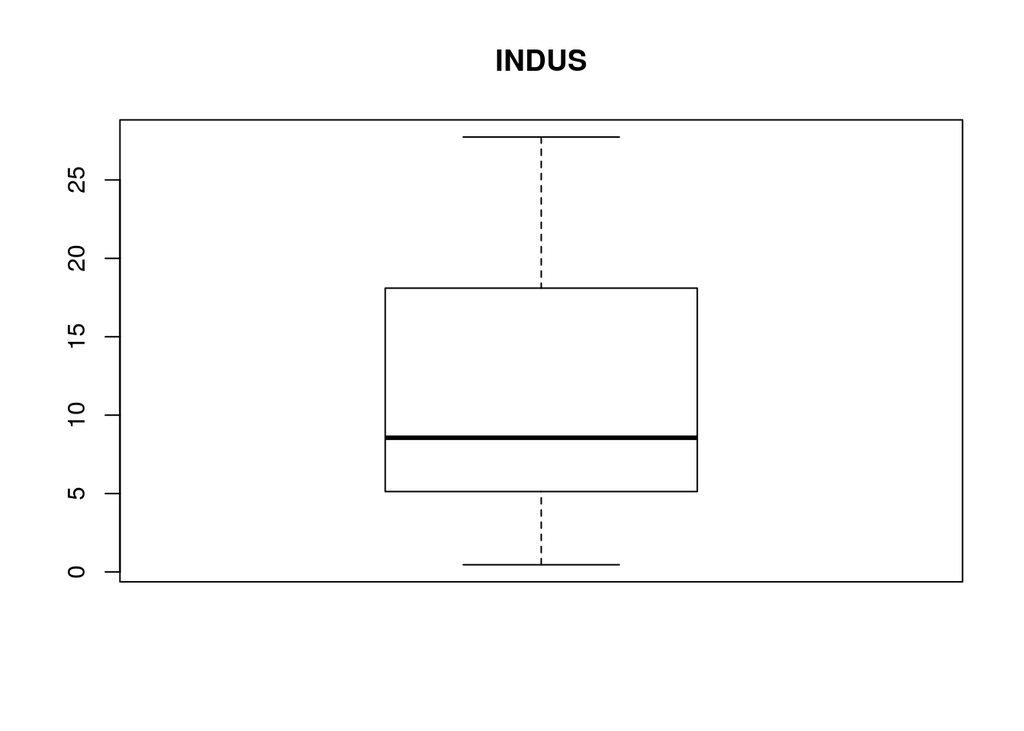

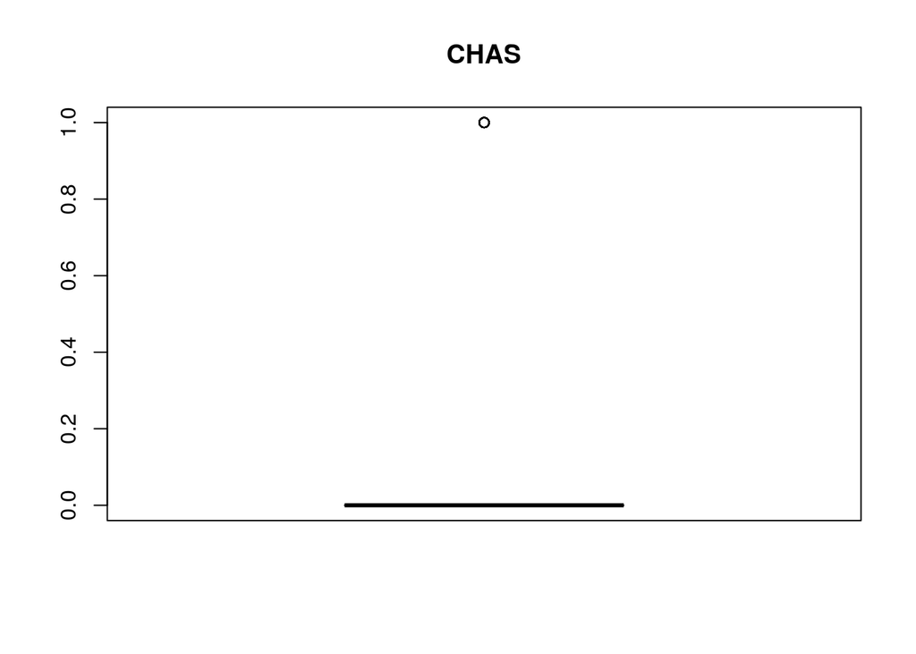

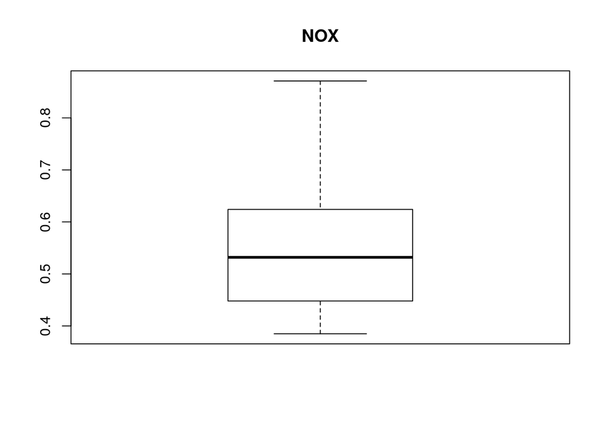

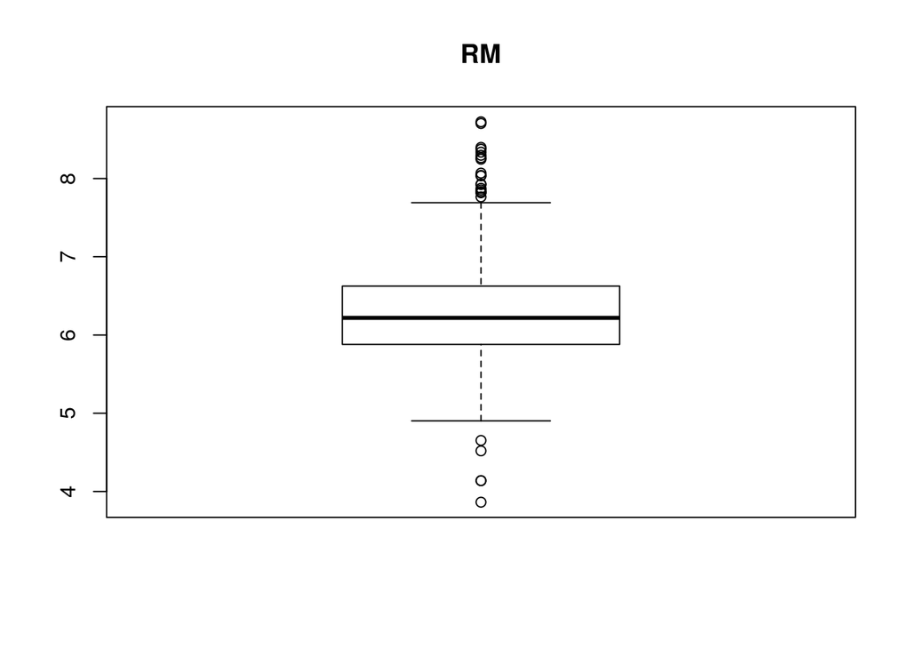

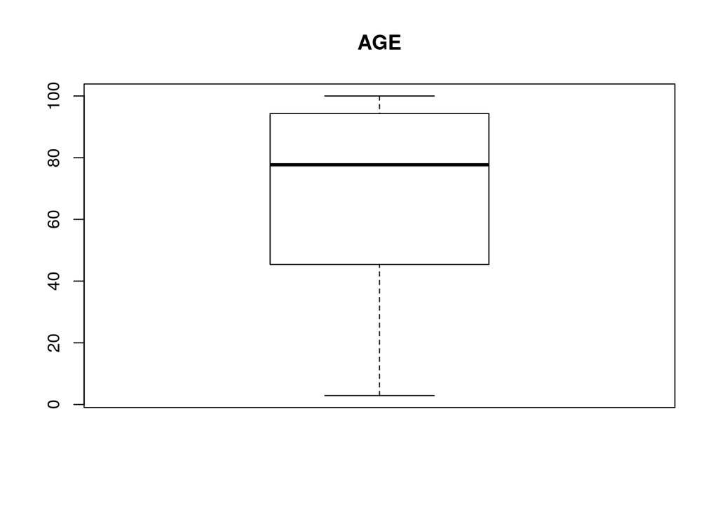

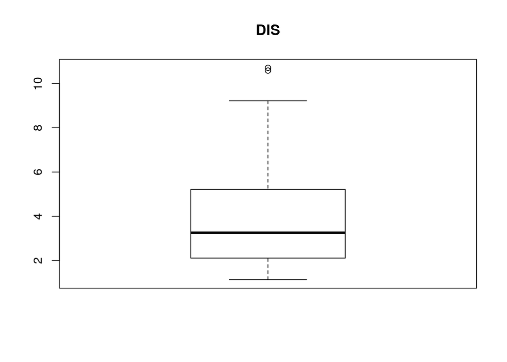

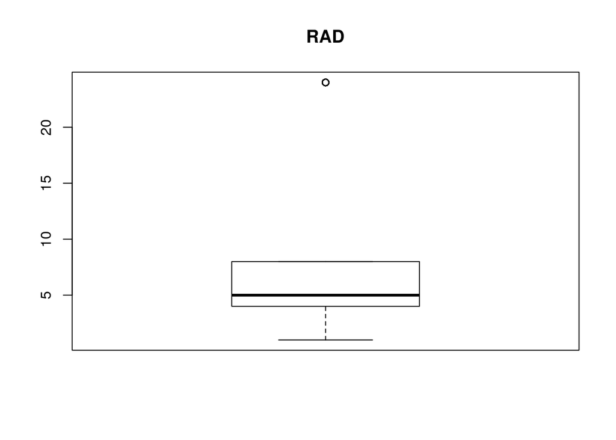

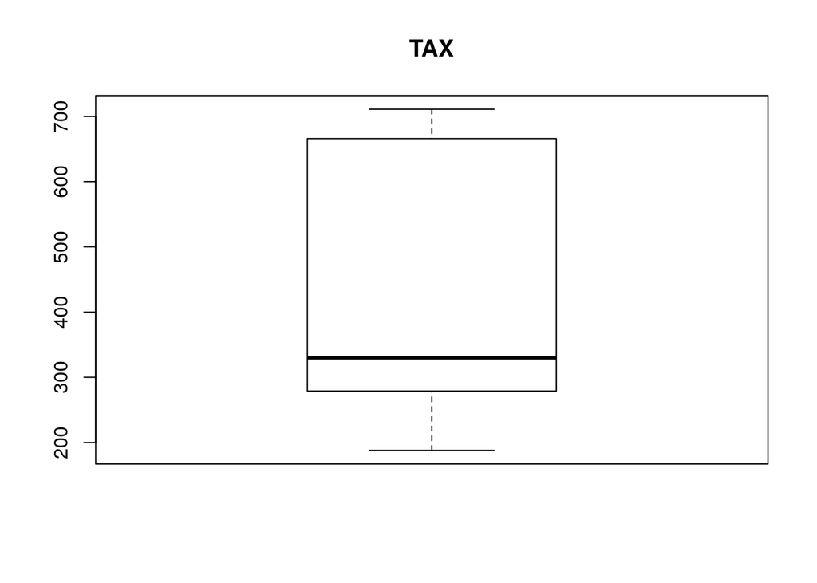

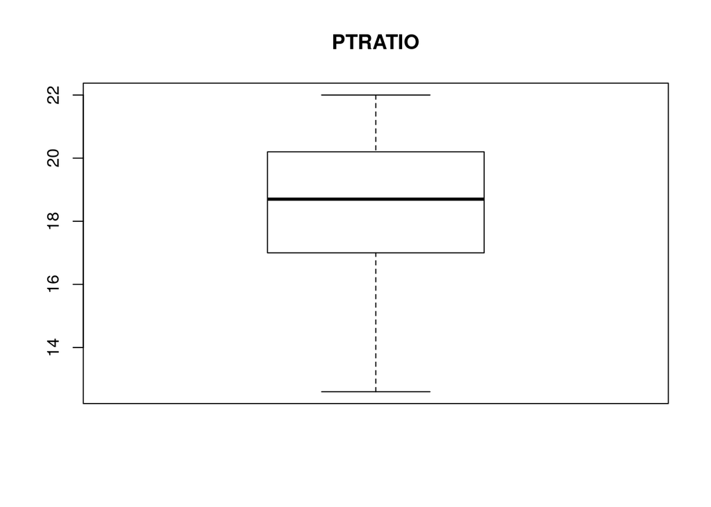

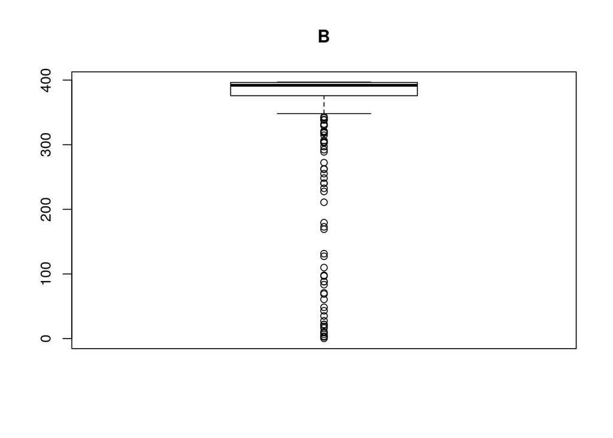

[1 more figures not shown]

```r
# Boxplots for each attribute
# par(mfrow=c(dispRow,dispCol))
for(i in 1:totAttr) {
    boxplot(X_train[,i], main=names(X_train)[i])
}
```

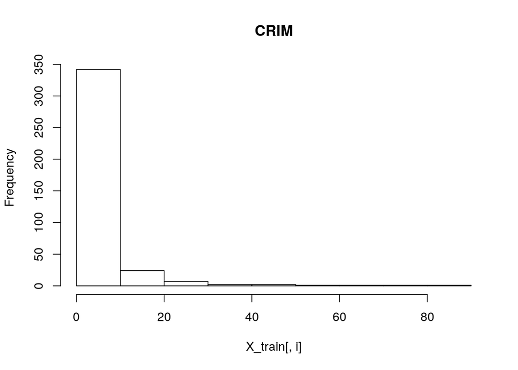

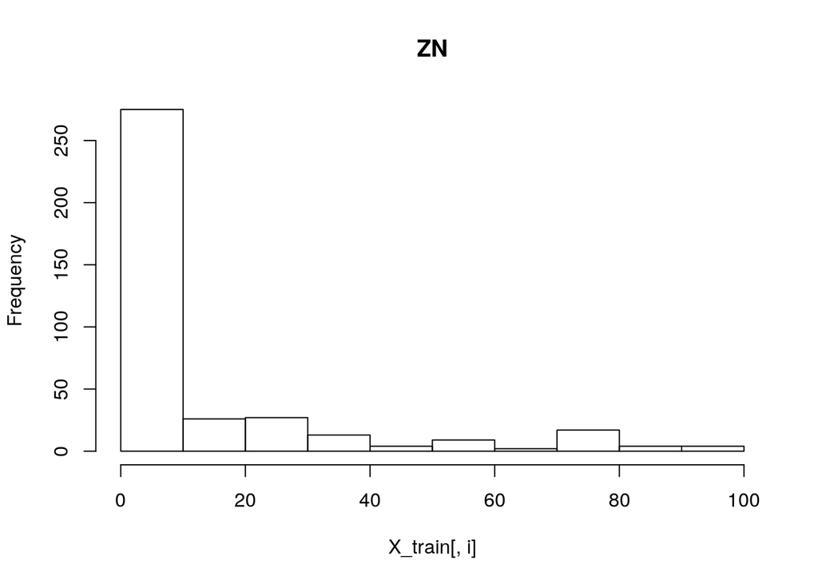

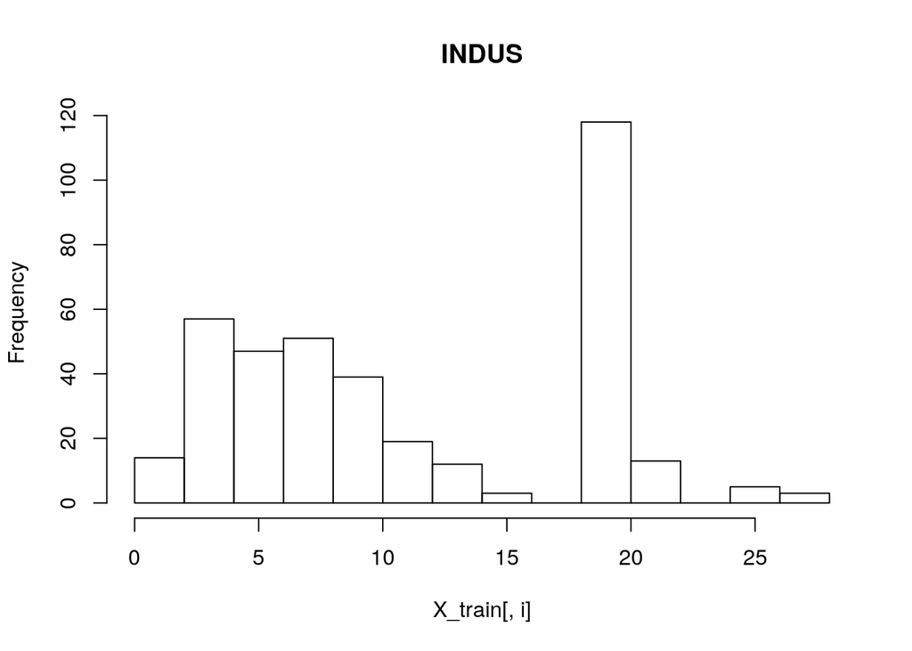

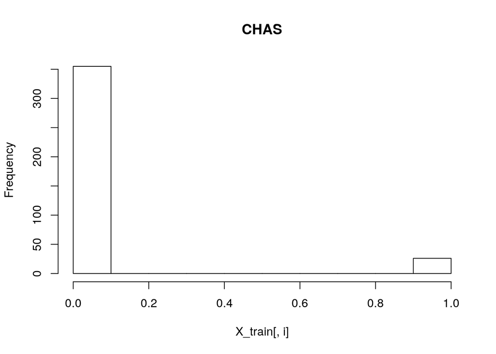

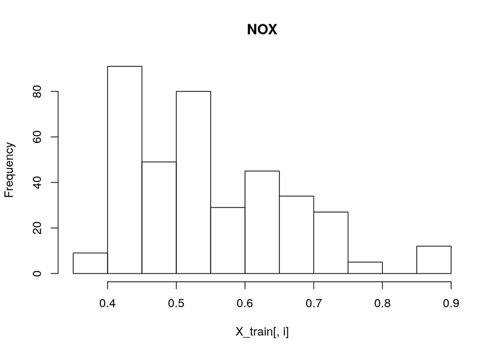

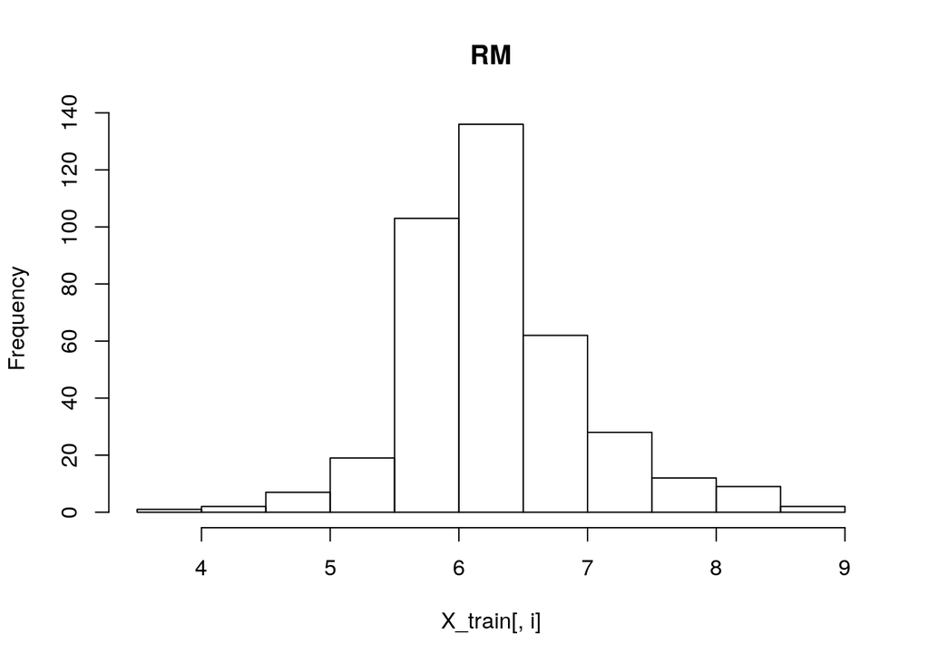

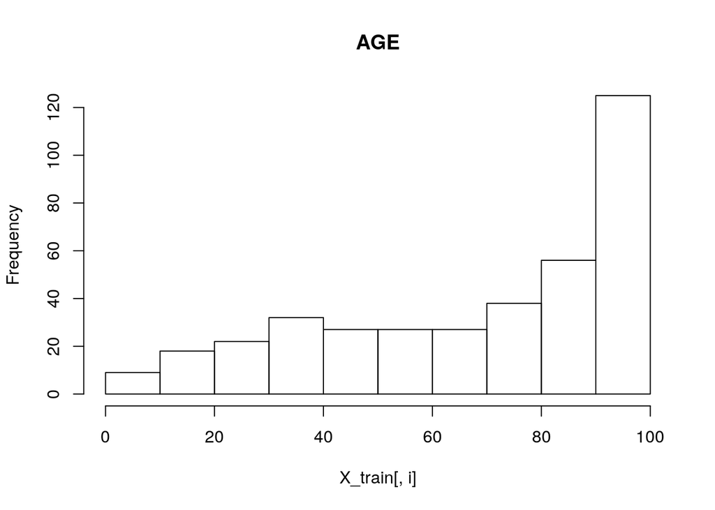

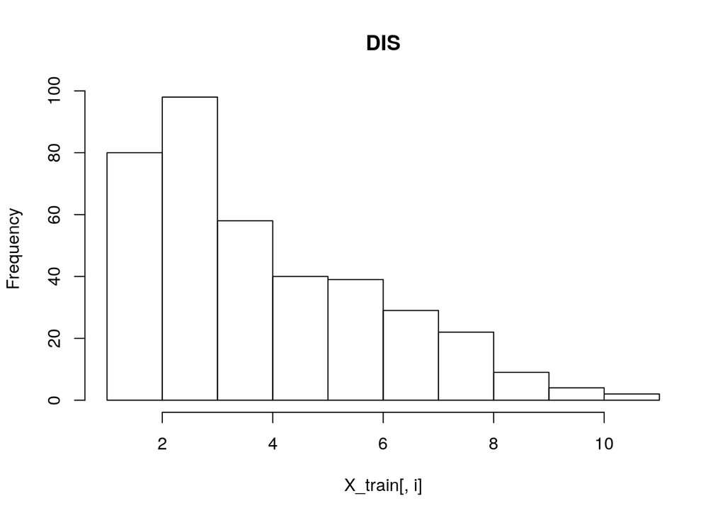

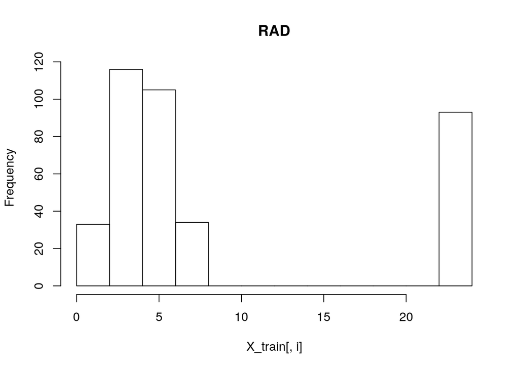

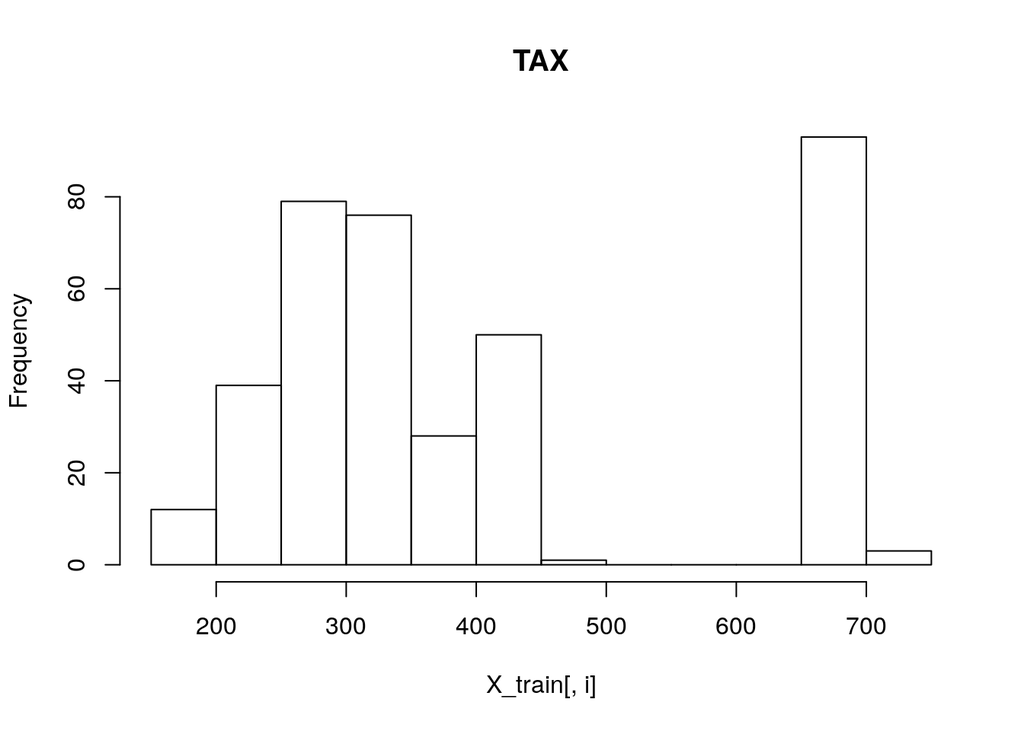

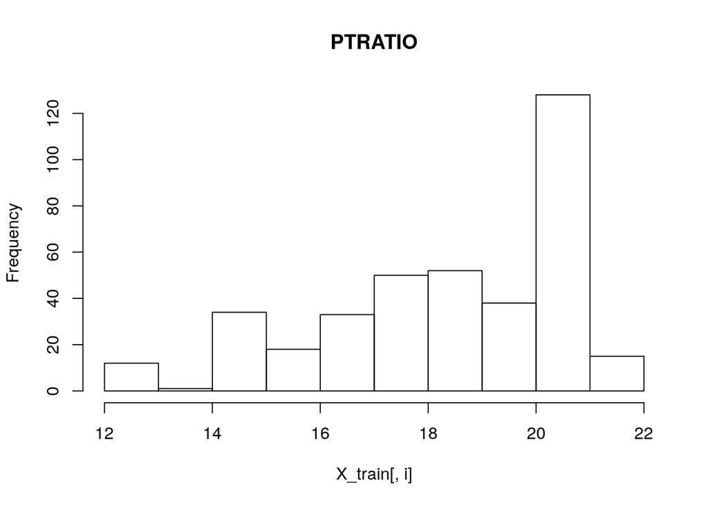

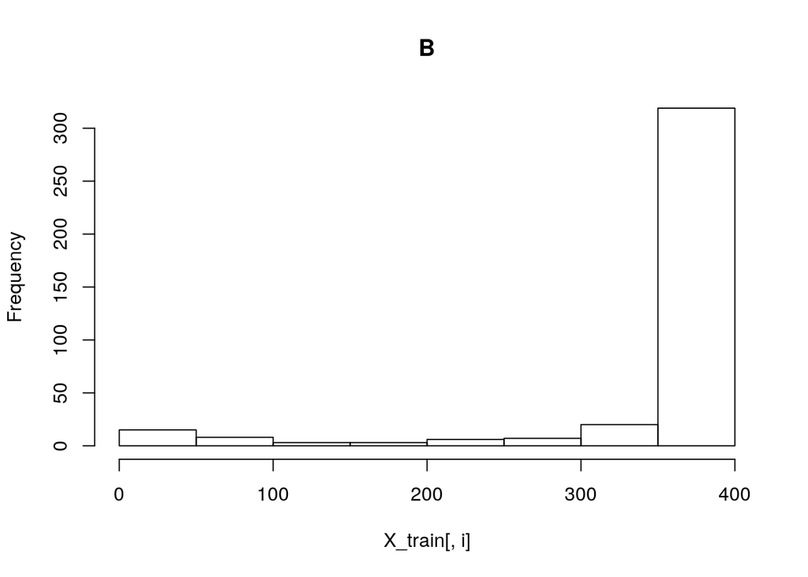

[1 more figures not shown]

```r
# Histograms each attribute
# par(mfrow=c(dispRow,dispCol))
for(i in 1:totAttr) {
    hist(X_train[,i], main=names(X_train)[i])
}
```